# Phase1_Group99

**VEHICLE TYPE PREDICTION USING VEHICLE SILHOUETTES**

**GROUP DETAILS**

**GROUP NAME:** Group 99

**GROUP MEMBERS:**

1. VIJAY CHALAMALA -- S3817359
2. VISHAL PATNAIK DAMODARAPATRUNI -- S3811521
3. SRI VENKATA MANIDEEPU MADDIPATI -- S3820822

# INTRODUCTION

The Vehicle Silhouettes dataset contains the measurements of different vehicles such as model cars, vans, and buses. This dataset is taken from OpenML repository at https://www.openml.org/d/54(Vanschoren, 2021).

## DATA SOURCE

The original source of dataset is collected from the Turing Institute, Glasgow, Scotland by Drs.Pete Mowforth and Barry Shepherd.

"This data was originally gathered at the TI in 1986-87 by JP Siebert. It was partially financed by Barr and Stroud Ltd. The original purpose was to find a method of distinguishing 3D objects within a 2D image by application of an ensemble of shape feature extractors to the 2D silhouettes of the objects. Measures of shape features extracted from example silhouettes of objects to be discriminated were used to generate a classification rule tree by means of computer induction" ("UCI Machine Learning Repository: Statlog (Vehicle Silhouettes) Data Set", 2021).

## DATASET DETAILS

The Features in the dataset are the measurements of Silhouettes which are measured using Hierarchical Image Processing System (HIPS). This system extracts the independent features utilising both classical moments-based measures such as scaled variance, skewness and kurtosis about the major/minor axes and heuristic measures such as hollows, circularity, rectangularity, and compactness. These features are collected using four "Corgie" model vehicles such as Chevrolet van, Saab 9000, a double decker bus, and an Opel Manta 400 which are classes. This dataset contains 19 features in which one is target feature or class variable and remaining 18 are independent attributes. A total of 946 instances are recorded among these 100 instances are reserved for validation by source and rest 846 are available in the dataset.

## DATASET FEATURES

| Feature Name | Data Type | Units | Description |
| --- | --- | --- | --- |
| Class | Nominal | Unknown | Contains four types of vehicles such as OPEL, SAAB, BUS, VAN |
| COMPACTNESS | Numeric | Unknown | This is calculated using the formula square of average perimeter divided by area i.e. (average perim) ^2/area |
| CIRCULARITY | Numeric | Unknown | This is calculated using the formula square of average radius divided by area i.e. (average radius) ^2/area |
| DISTANCE CIRCULARITY | Numeric | Unknown | This is calculated using the formula, area/(av.distance from border)**2 |
| RADIUS RATIO | Numeric | Unknown | This is calculated using the formula, (max.radius-min.radius)/av.radius |
| PR.AXIS ASPECT RATIO | Numeric | Unknown | This is calculated using the formula, (minor axis)/(major axis) |
| MAX.LENGTH ASPECT RATIO | Numeric | Unknown | This is calculated using the formula, (length perp. max length)/(max length) |
| SCATTER RATIO | Numeric | Unknown | This is calculated using the formula, (inertia about minor axis)/(inertia about major axis) |
| ELONGATEDNESS | Numeric | Unknown | This is calculated using the formula, area/(shrink width)**2 |
| PR.AXIS RECTANGULARITY | Numeric | Unknown | This is calculated using the formula, area/(pr.axis length*pr.axis width) |
| MAX.LENGTH RECTANGULARITY | Numeric | Unknown | This is calculated using the formula, area/(max.length*length perp. to this) |
| SCALED VARIANCE MAJOR | Numeric | Unknown | This is calculated using the formula, (2nd order moment about minor axis)/area along major axis |
| SCALED VARIANCE MINOR | Numeric | Unknown | This is calculated using the formula, (2nd order moment about major axis)/area along minor axis |
| SCALED RADIUS OF GYRATION | Numeric | Unknown | This is calculated using the formula, (maximum variance + minimum variance)/area |
| SKEWNESS ABOUT MAJOR | Numeric | Unknown | This is calculated using the formula, (3rd order moment about major axis)/sigma_min^3 major axis |
| SKEWNESS ABOUT MINOR | Numeric | Unknown | This is calculated using the formula, (3rd order moment about minor axis)/sigma_maj^3 minor axis |
| KURTOSIS ABOUT MINOR | Numeric | Unknown | This is calculated using the formula, (4th order moment about major axis)/sigma_min^4 minor axis |
| KURTOSIS ABOUT MAJOR | Numeric | Unknown | This is calculated using the formula, (4th order moment about minor axis)/sigma_maj^4 major axis |
| HOLLOWS RATIO | Numeric | Unknown | This is calculated using the formula, (area of hollows)/(area of bounding polygon) |

NOTE: -

1. Where sigma_maj^2 is the variance along the major axis and sigma_min^2 is the variance along the minor axis.
2. area of hollows= area of bounding poly-area of object.
3. The area of the bounding polygon is found as a side result of the computation to find the maximum length.

## TARGET FEATURE

Target feature is class variable which is a categorical variable. Therefore, this comes under classification problem.

# GOALS & OBJECTIVES

The aim of this project is to classify the given vehicle silhouettes into one of the four vehicle types.

# Data Cleaning and Pre - Processing

## Importing Packages.

```python
# Importing the required packages.
import pandas as pd
import numpy as np
import matplotlib.pyplot as plt
import seaborn as sns
from IPython.display import display, HTML
import warnings
warnings.filterwarnings("ignore")
```

## Loading Data

The dataset is downloaded from https://www.openml.org/data/get_csv/54/dataset_54_vehicle.arff and loaded into dataframe using pandas function.

```python
vehicle = pd.read_csv("Data_Group99.csv", encoding = "unicode_escape")


print(f"Shape : {vehicle.shape}")# gives the dimentions of the data frame.

vehicle# Displays the data in the data frame.
```

```
Shape : (846, 19)
```

|  | COMPACTNESS | CIRCULARITY | DISTANCE_CIRCULARITY | RADIUS_RATIO | PR.AXIS_ASPECT_RATIO | MAX.LENGTH_ASPECT_RATIO | SCATTER_RATIO | ELONGATEDNESS | PR.AXIS_RECTANGULARITY | MAX.LENGTH_RECTANGULARITY | SCALED_VARIANCE_MAJOR | SCALED_VARIANCE_MINOR | SCALED_RADIUS_OF_GYRATION | SKEWNESS_ABOUT_MAJOR | SKEWNESS_ABOUT_MINOR | KURTOSIS_ABOUT_MAJOR | KURTOSIS_ABOUT_MINOR | HOLLOWS_RATIO | Class |
| --- | --- | --- | --- | --- | --- | --- | --- | --- | --- | --- | --- | --- | --- | --- | --- | --- | --- | --- | --- |
| 0 | 95 | 48 | 83 | 178 | 72 | 10 | 162 | 42 | 20 | 159 | 176 | 379 | 184 | 70 | 6 | 16 | 187 | 197 | van |
| 1 | 91 | 41 | 84 | 141 | 57 | 9 | 149 | 45 | 19 | 143 | 170 | 330 | 158 | 72 | 9 | 14 | 189 | 199 | van |
| 2 | 104 | 50 | 106 | 209 | 66 | 10 | 207 | 32 | 23 | 158 | 223 | 635 | 220 | 73 | 14 | 9 | 188 | 196 | saab |
| 3 | 93 | 41 | 82 | 159 | 63 | 9 | 144 | 46 | 19 | 143 | 160 | 309 | 127 | 63 | 6 | 10 | 199 | 207 | van |
| 4 | 85 | 44 | 70 | 205 | 103 | 52 | 149 | 45 | 19 | 144 | 241 | 325 | 188 | 127 | 9 | 11 | 180 | 183 | bus |
| ... | ... | ... | ... | ... | ... | ... | ... | ... | ... | ... | ... | ... | ... | ... | ... | ... | ... | ... | ... |
| 841 | 93 | 39 | 87 | 183 | 64 | 8 | 169 | 40 | 20 | 134 | 200 | 422 | 149 | 72 | 7 | 25 | 188 | 195 | saab |
| 842 | 89 | 46 | 84 | 163 | 66 | 11 | 159 | 43 | 20 | 159 | 173 | 368 | 176 | 72 | 1 | 20 | 186 | 197 | van |
| 843 | 106 | 54 | 101 | 222 | 67 | 12 | 222 | 30 | 25 | 173 | 228 | 721 | 200 | 70 | 3 | 4 | 187 | 201 | saab |
| 844 | 86 | 36 | 78 | 146 | 58 | 7 | 135 | 50 | 18 | 124 | 155 | 270 | 148 | 66 | 0 | 25 | 190 | 195 | saab |
| 845 | 85 | 36 | 66 | 123 | 55 | 5 | 120 | 56 | 17 | 128 | 140 | 212 | 131 | 73 | 1 | 18 | 186 | 190 | van |

846 rows × 19 columns

## Checking data types

```python
vehicle.info() # Gives the type of each column.
```

```
<class 'pandas.core.frame.DataFrame'>
RangeIndex: 846 entries, 0 to 845
Data columns (total 19 columns):
COMPACTNESS                  846 non-null int64
CIRCULARITY                  846 non-null int64
DISTANCE_CIRCULARITY         846 non-null int64
RADIUS_RATIO                 846 non-null int64
PR.AXIS_ASPECT_RATIO         846 non-null int64
MAX.LENGTH_ASPECT_RATIO      846 non-null int64
SCATTER_RATIO                846 non-null int64
ELONGATEDNESS                846 non-null int64
PR.AXIS_RECTANGULARITY       846 non-null int64
MAX.LENGTH_RECTANGULARITY    846 non-null int64
SCALED_VARIANCE_MAJOR        846 non-null int64
SCALED_VARIANCE_MINOR        846 non-null int64
SCALED_RADIUS_OF_GYRATION    846 non-null int64
SKEWNESS_ABOUT_MAJOR         846 non-null int64
SKEWNESS_ABOUT_MINOR         846 non-null int64
KURTOSIS_ABOUT_MAJOR         846 non-null int64
KURTOSIS_ABOUT_MINOR         846 non-null int64
HOLLOWS_RATIO                846 non-null int64
Class                        846 non-null object
dtypes: int64(18), object(1)
memory usage: 125.7+ KB
```

On verifying attribute datatypes, the target variable "Class" which is supposed to be a "category" is of type "object". Hence, it is converted to the required data type "Category".

```python
# Converting object type to category.
vehicle['Class'] = vehicle['Class'].astype('category')
```

```python
# Rechecking datatypes.
vehicle.info()
```

```
<class 'pandas.core.frame.DataFrame'>
RangeIndex: 846 entries, 0 to 845
Data columns (total 19 columns):
COMPACTNESS                  846 non-null int64
CIRCULARITY                  846 non-null int64
DISTANCE_CIRCULARITY         846 non-null int64
RADIUS_RATIO                 846 non-null int64
PR.AXIS_ASPECT_RATIO         846 non-null int64
MAX.LENGTH_ASPECT_RATIO      846 non-null int64
SCATTER_RATIO                846 non-null int64
ELONGATEDNESS                846 non-null int64
PR.AXIS_RECTANGULARITY       846 non-null int64
MAX.LENGTH_RECTANGULARITY    846 non-null int64
SCALED_VARIANCE_MAJOR        846 non-null int64
SCALED_VARIANCE_MINOR        846 non-null int64
SCALED_RADIUS_OF_GYRATION    846 non-null int64
SKEWNESS_ABOUT_MAJOR         846 non-null int64
SKEWNESS_ABOUT_MINOR         846 non-null int64
KURTOSIS_ABOUT_MAJOR         846 non-null int64
KURTOSIS_ABOUT_MINOR         846 non-null int64
HOLLOWS_RATIO                846 non-null int64
Class                        846 non-null category
dtypes: category(1), int64(18)
memory usage: 120.1 KB
```

Now the data types of all features are in required format.

Inspecting on data for cleaning

```python
vehicle
```

|  | COMPACTNESS | CIRCULARITY | DISTANCE_CIRCULARITY | RADIUS_RATIO | PR.AXIS_ASPECT_RATIO | MAX.LENGTH_ASPECT_RATIO | SCATTER_RATIO | ELONGATEDNESS | PR.AXIS_RECTANGULARITY | MAX.LENGTH_RECTANGULARITY | SCALED_VARIANCE_MAJOR | SCALED_VARIANCE_MINOR | SCALED_RADIUS_OF_GYRATION | SKEWNESS_ABOUT_MAJOR | SKEWNESS_ABOUT_MINOR | KURTOSIS_ABOUT_MAJOR | KURTOSIS_ABOUT_MINOR | HOLLOWS_RATIO | Class |
| --- | --- | --- | --- | --- | --- | --- | --- | --- | --- | --- | --- | --- | --- | --- | --- | --- | --- | --- | --- |
| 0 | 95 | 48 | 83 | 178 | 72 | 10 | 162 | 42 | 20 | 159 | 176 | 379 | 184 | 70 | 6 | 16 | 187 | 197 | van |
| 1 | 91 | 41 | 84 | 141 | 57 | 9 | 149 | 45 | 19 | 143 | 170 | 330 | 158 | 72 | 9 | 14 | 189 | 199 | van |
| 2 | 104 | 50 | 106 | 209 | 66 | 10 | 207 | 32 | 23 | 158 | 223 | 635 | 220 | 73 | 14 | 9 | 188 | 196 | saab |
| 3 | 93 | 41 | 82 | 159 | 63 | 9 | 144 | 46 | 19 | 143 | 160 | 309 | 127 | 63 | 6 | 10 | 199 | 207 | van |
| 4 | 85 | 44 | 70 | 205 | 103 | 52 | 149 | 45 | 19 | 144 | 241 | 325 | 188 | 127 | 9 | 11 | 180 | 183 | bus |
| ... | ... | ... | ... | ... | ... | ... | ... | ... | ... | ... | ... | ... | ... | ... | ... | ... | ... | ... | ... |
| 841 | 93 | 39 | 87 | 183 | 64 | 8 | 169 | 40 | 20 | 134 | 200 | 422 | 149 | 72 | 7 | 25 | 188 | 195 | saab |
| 842 | 89 | 46 | 84 | 163 | 66 | 11 | 159 | 43 | 20 | 159 | 173 | 368 | 176 | 72 | 1 | 20 | 186 | 197 | van |
| 843 | 106 | 54 | 101 | 222 | 67 | 12 | 222 | 30 | 25 | 173 | 228 | 721 | 200 | 70 | 3 | 4 | 187 | 201 | saab |
| 844 | 86 | 36 | 78 | 146 | 58 | 7 | 135 | 50 | 18 | 124 | 155 | 270 | 148 | 66 | 0 | 25 | 190 | 195 | saab |
| 845 | 85 | 36 | 66 | 123 | 55 | 5 | 120 | 56 | 17 | 128 | 140 | 212 | 131 | 73 | 1 | 18 | 186 | 190 | van |

846 rows × 19 columns

## Checking the categorical data for any data changes.

```python
vehicle["Class"].unique()
```

```
[van, saab, bus, opel]
Categories (4, object): [van, saab, bus, opel]
```

The categorical variable "Class" has no special characters or any mis-spelt data.

## Checking Typo / Missing values.

```python
vehicle.isnull().sum()
```

```
COMPACTNESS                  0
CIRCULARITY                  0
DISTANCE_CIRCULARITY         0
RADIUS_RATIO                 0
PR.AXIS_ASPECT_RATIO         0
MAX.LENGTH_ASPECT_RATIO      0
SCATTER_RATIO                0
ELONGATEDNESS                0
PR.AXIS_RECTANGULARITY       0
MAX.LENGTH_RECTANGULARITY    0
SCALED_VARIANCE_MAJOR        0
SCALED_VARIANCE_MINOR        0
SCALED_RADIUS_OF_GYRATION    0
SKEWNESS_ABOUT_MAJOR         0
SKEWNESS_ABOUT_MINOR         0
KURTOSIS_ABOUT_MAJOR         0
KURTOSIS_ABOUT_MINOR         0
HOLLOWS_RATIO                0
Class                        0
dtype: int64
```

There are no missing values.

## Checking outliers

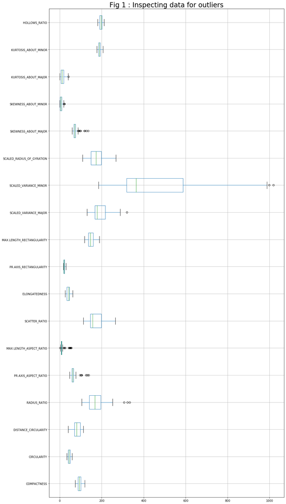

```python
vehicle.boxplot(figsize=(15, 32), vert = False)
plt.title("Fig 1 : Inspecting data for outliers", size = 24)
plt.show()
```

On observing above boxplots we can identify outliers in the below features,

RADIUS_RATIO

PR.AXIS_ASPECT_RATIO

MAX.LENGTH_ASPECT_RATIO

SCALED_VARIANCE_MAJOR

SCALED_VARIANCE_MINOR

SKEWNESS_ABOUT_MAJOR

SKEWNESS_ABOUT_MINOR

KURTOSIS_ABOUT_MAJOR

These outliers are replaced with their corresponding mean values instead of removing the entire silhouette or replacing the out layer with upper or lower boundary or median.

## Removing Outliers

```python
for i in vehicle.columns[:-1]:
    q1 = vehicle[i].quantile(0.25)
    q3 = vehicle[i].quantile(0.75)
    iqr = q3 - q1

    low = q1 - 1.5 * iqr
    high = q3 + 1.5 * iqr

    vehicle.loc[(vehicle[i] < low) | (vehicle[i] > high), i] = vehicle[i].mean()
```

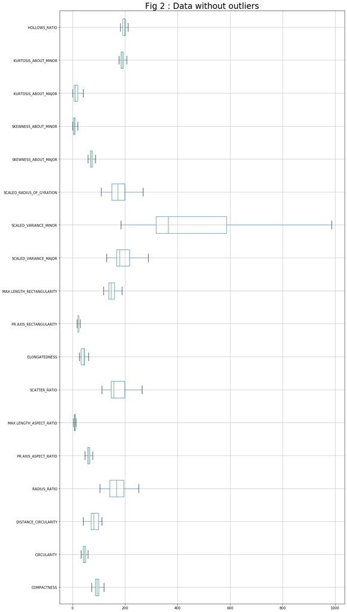

```python
vehicle.boxplot(figsize=(15, 32), vert = False)
plt.title("Fig 2 : Data without outliers", size = 24)
plt.show()
```

## Checking White space characters

```python
print(vehicle["Class"].str.isspace().sum())
```

```
0
```

The categorical variable "Class" has no white spaces.

## Upper Case conversion

```python
vehicle["Class"] = vehicle["Class"].str.upper()
vehicle
```

|  | COMPACTNESS | CIRCULARITY | DISTANCE_CIRCULARITY | RADIUS_RATIO | PR.AXIS_ASPECT_RATIO | MAX.LENGTH_ASPECT_RATIO | SCATTER_RATIO | ELONGATEDNESS | PR.AXIS_RECTANGULARITY | MAX.LENGTH_RECTANGULARITY | SCALED_VARIANCE_MAJOR | SCALED_VARIANCE_MINOR | SCALED_RADIUS_OF_GYRATION | SKEWNESS_ABOUT_MAJOR | SKEWNESS_ABOUT_MINOR | KURTOSIS_ABOUT_MAJOR | KURTOSIS_ABOUT_MINOR | HOLLOWS_RATIO | Class |
| --- | --- | --- | --- | --- | --- | --- | --- | --- | --- | --- | --- | --- | --- | --- | --- | --- | --- | --- | --- |
| 0 | 95.0 | 48.0 | 83.0 | 178.0 | 72.000000 | 10.000000 | 162.0 | 42.0 | 20.0 | 159.0 | 176.0 | 379.0 | 184.0 | 70.000000 | 6.0 | 16.0 | 187.0 | 197.0 | VAN |
| 1 | 91.0 | 41.0 | 84.0 | 141.0 | 57.000000 | 9.000000 | 149.0 | 45.0 | 19.0 | 143.0 | 170.0 | 330.0 | 158.0 | 72.000000 | 9.0 | 14.0 | 189.0 | 199.0 | VAN |
| 2 | 104.0 | 50.0 | 106.0 | 209.0 | 66.000000 | 10.000000 | 207.0 | 32.0 | 23.0 | 158.0 | 223.0 | 635.0 | 220.0 | 73.000000 | 14.0 | 9.0 | 188.0 | 196.0 | SAAB |
| 3 | 93.0 | 41.0 | 82.0 | 159.0 | 63.000000 | 9.000000 | 144.0 | 46.0 | 19.0 | 143.0 | 160.0 | 309.0 | 127.0 | 63.000000 | 6.0 | 10.0 | 199.0 | 207.0 | VAN |
| 4 | 85.0 | 44.0 | 70.0 | 205.0 | 61.693853 | 8.567376 | 149.0 | 45.0 | 19.0 | 144.0 | 241.0 | 325.0 | 188.0 | 72.462175 | 9.0 | 11.0 | 180.0 | 183.0 | BUS |
| ... | ... | ... | ... | ... | ... | ... | ... | ... | ... | ... | ... | ... | ... | ... | ... | ... | ... | ... | ... |
| 841 | 93.0 | 39.0 | 87.0 | 183.0 | 64.000000 | 8.000000 | 169.0 | 40.0 | 20.0 | 134.0 | 200.0 | 422.0 | 149.0 | 72.000000 | 7.0 | 25.0 | 188.0 | 195.0 | SAAB |
| 842 | 89.0 | 46.0 | 84.0 | 163.0 | 66.000000 | 11.000000 | 159.0 | 43.0 | 20.0 | 159.0 | 173.0 | 368.0 | 176.0 | 72.000000 | 1.0 | 20.0 | 186.0 | 197.0 | VAN |
| 843 | 106.0 | 54.0 | 101.0 | 222.0 | 67.000000 | 12.000000 | 222.0 | 30.0 | 25.0 | 173.0 | 228.0 | 721.0 | 200.0 | 70.000000 | 3.0 | 4.0 | 187.0 | 201.0 | SAAB |
| 844 | 86.0 | 36.0 | 78.0 | 146.0 | 58.000000 | 7.000000 | 135.0 | 50.0 | 18.0 | 124.0 | 155.0 | 270.0 | 148.0 | 66.000000 | 0.0 | 25.0 | 190.0 | 195.0 | SAAB |
| 845 | 85.0 | 36.0 | 66.0 | 123.0 | 55.000000 | 5.000000 | 120.0 | 56.0 | 17.0 | 128.0 | 140.0 | 212.0 | 131.0 | 73.000000 | 1.0 | 18.0 | 186.0 | 190.0 | VAN |

846 rows × 19 columns

All the other columns are numeric. Hence only "Class" is changed.

The data is cleaned and preprocessed. Hence, it is ready for further analysis.

# Data Exploration and Visualisation

## Descriptive Statistics

```python
#Refered from ("Regression Case Study | www.featureranking.com", 2021)
display(HTML('<b>Table 1: Descriptive Statistics on Numeric features</b>'))
vehicle.describe()
```

**Table 1: Descriptive Statistics on Numeric features**

|  | COMPACTNESS | CIRCULARITY | DISTANCE_CIRCULARITY | RADIUS_RATIO | PR.AXIS_ASPECT_RATIO | MAX.LENGTH_ASPECT_RATIO | SCATTER_RATIO | ELONGATEDNESS | PR.AXIS_RECTANGULARITY | MAX.LENGTH_RECTANGULARITY | SCALED_VARIANCE_MAJOR | SCALED_VARIANCE_MINOR | SCALED_RADIUS_OF_GYRATION | SKEWNESS_ABOUT_MAJOR | SKEWNESS_ABOUT_MINOR | KURTOSIS_ABOUT_MAJOR | KURTOSIS_ABOUT_MINOR | HOLLOWS_RATIO |
| --- | --- | --- | --- | --- | --- | --- | --- | --- | --- | --- | --- | --- | --- | --- | --- | --- | --- | --- |
| count | 846.000000 | 846.000000 | 846.000000 | 846.000000 | 846.000000 | 846.000000 | 846.000000 | 846.000000 | 846.000000 | 846.000000 | 846.000000 | 846.000000 | 846.00000 | 846.000000 | 846.000000 | 846.000000 | 846.000000 | 846.000000 |
| mean | 93.678487 | 44.861702 | 82.088652 | 168.404046 | 61.177956 | 8.126922 | 168.839243 | 40.933806 | 20.582742 | 147.998818 | 188.470006 | 438.568348 | 174.70331 | 71.979826 | 6.168469 | 12.565720 | 188.932624 | 195.632388 |
| std | 8.234474 | 6.169866 | 15.771533 | 32.222517 | 5.623709 | 2.064796 | 33.244978 | 7.811560 | 2.592138 | 14.515652 | 31.067449 | 174.511867 | 32.54649 | 6.182516 | 4.589891 | 8.877577 | 6.163949 | 7.438797 |
| min | 73.000000 | 33.000000 | 40.000000 | 104.000000 | 47.000000 | 3.000000 | 112.000000 | 26.000000 | 17.000000 | 118.000000 | 130.000000 | 184.000000 | 109.00000 | 59.000000 | 0.000000 | 0.000000 | 176.000000 | 181.000000 |
| 25% | 87.000000 | 40.000000 | 70.000000 | 141.000000 | 57.000000 | 7.000000 | 146.250000 | 33.000000 | 19.000000 | 137.000000 | 167.000000 | 318.250000 | 149.00000 | 67.000000 | 2.000000 | 5.000000 | 184.000000 | 190.250000 |
| 50% | 93.000000 | 44.000000 | 80.000000 | 167.000000 | 61.000000 | 8.000000 | 157.000000 | 43.000000 | 20.000000 | 146.000000 | 178.500000 | 364.000000 | 173.00000 | 71.500000 | 6.000000 | 11.000000 | 188.000000 | 197.000000 |
| 75% | 100.000000 | 49.000000 | 98.000000 | 195.000000 | 65.000000 | 10.000000 | 198.000000 | 46.000000 | 23.000000 | 159.000000 | 217.000000 | 586.000000 | 198.00000 | 75.000000 | 9.000000 | 19.000000 | 193.000000 | 201.000000 |
| max | 119.000000 | 59.000000 | 112.000000 | 252.000000 | 76.000000 | 13.000000 | 265.000000 | 61.000000 | 29.000000 | 188.000000 | 288.000000 | 987.000000 | 268.00000 | 87.000000 | 19.000000 | 40.000000 | 206.000000 | 211.000000 |

## Visualization

```python
import matplotlib.pyplot as plt
import seaborn as sns
```

### Understanding Categorical variable

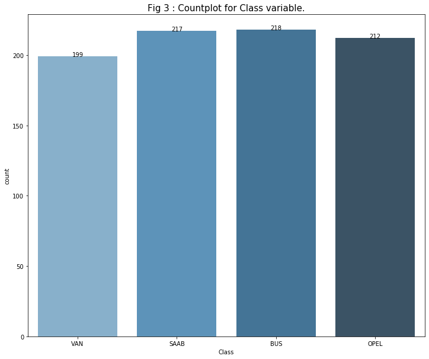

```python
fig, ax1 = plt.subplots(figsize = (12, 10))

graph = sns.countplot(ax = ax1, x = 'Class', data = vehicle, palette="Blues_d")

graph.set_title("Fig 3 : Countplot for Class variable.", fontsize = 15)

graph.set_xticklabels(graph.get_xticklabels())

i = 0

for i in graph.patches:
    height = i.get_height()
    graph.text(i.get_x() + i.get_width()/2., height + 0.1,height ,ha="center")
```

Most of the Silhouettes are of category BUS and the least are of VAN

VAN - 199

SAAB - 217

Bus - 218

OPEL - 212

### Understanding Descriptive variables

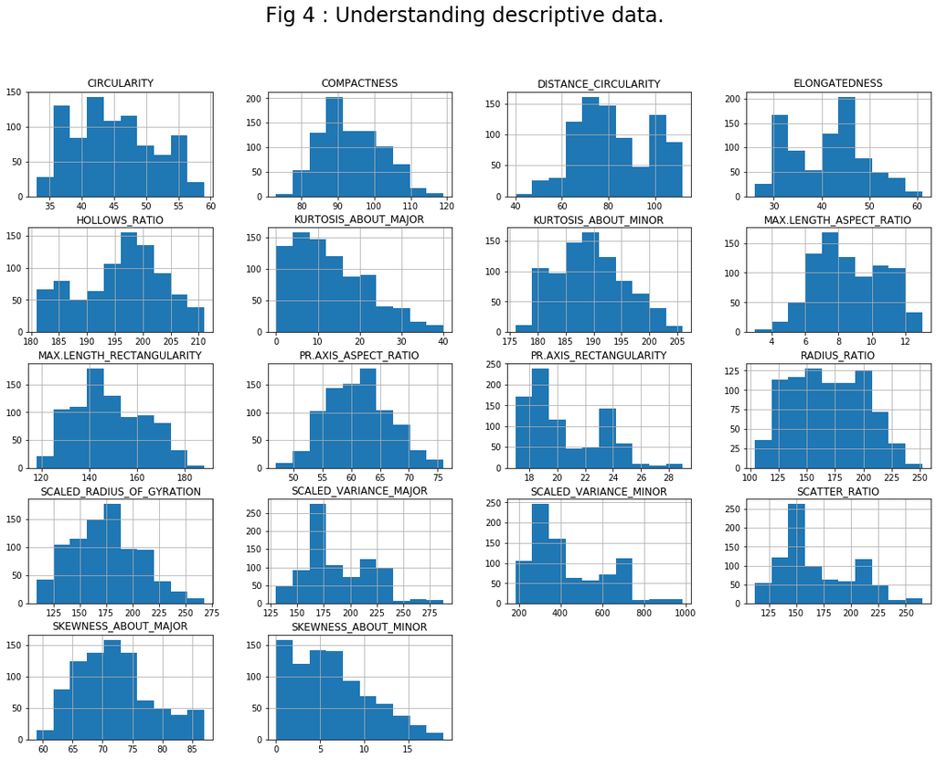

```python
vehicle.hist(figsize = (19, 14))

plt.suptitle("Fig 4 : Understanding descriptive data.", size = 24)
plt.show()
```

The data is not normalised and is to be scalled. This data normalisation and transformations are done in the later phases.

• Circularity: circularity ranges from 33 to 60 and the highest circularity lies between 40 – 45.

• Compactness: Compactness ranges from 70 to 120 and the maximum compactness achieved in 90.

• Distance_circularity: Distance circularity ranges from 40 to 110 and the highest Distance circularity is achieved at 70.

• Elongatedness: Elongatedness ranges from 25 to 60 and the maximum elongatedness is achieved at 45.

• Hollows_ratio: Hollows_ratio ranges form 180 to 210 and the maximum hollow ratio is achieved between 195 and 200.

• Kurtosis_about_major: Kurtosis major ranges from 0 to 40 and majority lies between 0 and 10.

• Kurtosis_about_minor: Kurtosis minor ranges from 175 to 205 and the maximum is achieved at 190.

• Max.length_Aspect_ratio: Maximum length of aspect ration lies from 0 to 12 and the maximum is reached at 7.

• Max.length_Rectangularity: Maximum length of rectangularity ranges from 120 to 180 but highest rectangularity is achieved at 140.

• PR.Axis_Aspect_ratio: PR Axis Aspect ratio ranges from 50 to 75 whereas the maximum aspect ratio is achieved between 60-65.

• PR.Axis_Rectangularity: PR.Axis Rectangularity ranges from 17 to 28 and the maximum rectangularity lies between 18 to 20.

• Radius_ratio: radius ratio for any vehicle ranges from 100 to 250 and the maximum radius is achieved at 150.

• Scaled_Radius_of_gyration: Scaled Radius of gyration ranges from 110 to 270 and the maximum radius is achieved at 175.

• Scaled_Variance_Major: Scaled Variance Major ranges from 125 to 275 and the maximum variance major is achieved at 175.

• Scaled_Variance_Minor: : Scaled Variance Minor ranges from 200 to 1000 and the maximum variance for minor is achieved at 300.

• Scatter_Ratio: Scatter ratio ranges from 125 to 250 and the maximum scatter ratio is seen at 150.

• Skewness_About_major: Skewness about major ranges from 60 to 85 and the maximum skewness about major is achieved at 70- 75.

• Skewness_About_minor: Skewness about minor ranges from 0 - 15 and the maximum skewness about minor is achieved at 0.

### Univariate Visualisation

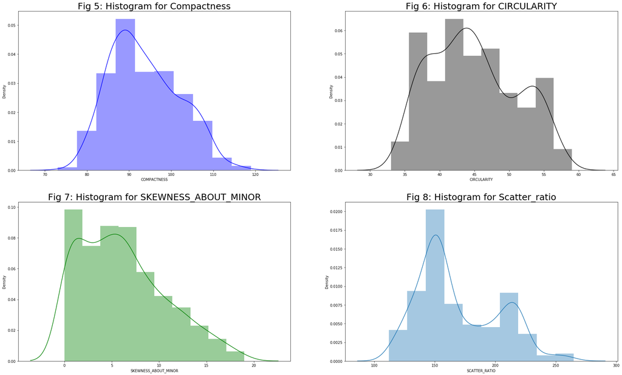

```python
f, ax = plt.subplots(2, 2, figsize=(30, 18))

sns.distplot(vehicle['COMPACTNESS'], color = "blue", kde = True, bins=10, ax = ax[0][0]).set_title('Fig 5: Histogram for Compactness', fontsize = 25)

sns.distplot(vehicle['CIRCULARITY'], color = "black", kde = True, bins=10, ax = ax[0][1]).set_title('Fig 6: Histogram for CIRCULARITY', fontsize = 25)

sns.distplot(vehicle['SKEWNESS_ABOUT_MINOR'], color = "green", kde = True, bins=10, ax = ax[1][0]).set_title('Fig 7: Histogram for SKEWNESS_ABOUT_MINOR', fontsize = 25)

sns.distplot(vehicle['SCATTER_RATIO'], kde = True, bins=10, ax= ax[1][1]).set_title('Fig 8: Histogram for Scatter_ratio', fontsize = 25)
```

1. Compactness ranges from 70 to 120 and the maximum compactness is achieved at 90.
2. Circularity ranges from 30 to 60 and the maximum circularity is achieved at 45.
3. Skewness about minor ranges from 0 to 20 and the maximum is achieved at 5.
4. Scatter ratio ranges from 100 to 300 and the maximum scatter ratio is achieved at 150.

### Multi-variate Visualisation

**2 Variable Visualisation**

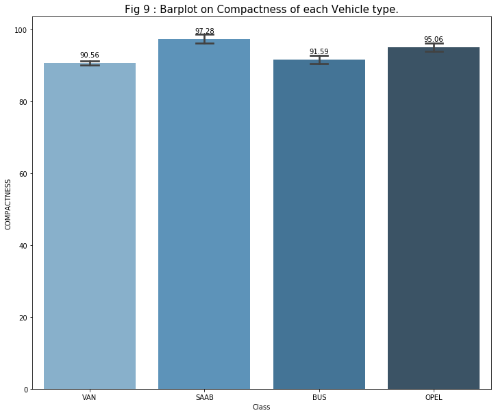

```python
fig = plt.subplots(figsize = (12, 10))

graph = sns.barplot(x = "Class", y = "COMPACTNESS", data = vehicle, palette = "Blues_d", capsize = .15)

graph.set_title("Fig 9 : Barplot on Compactness of each Vehicle type.", fontsize = 15)

graph.set_xticklabels(graph.get_xticklabels())

i = 0

for i in graph.patches:
    height = round(i.get_height(), 2)
    graph.text(i.get_x() + i.get_width()/2., height + 1.7, height, ha = "center")
```

Among different class of vehicles like van, saab, bus and opel. Saab has more compactness when compared to other vehicles in the class and van stands out with the least compactness within the class.

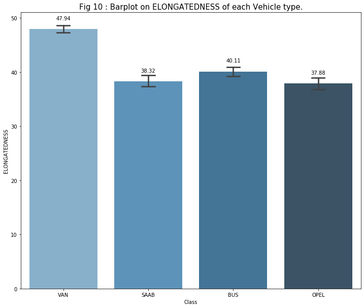

```python
fig = plt.subplots(figsize = (12, 10))

graph = sns.barplot(x = "Class", y = "ELONGATEDNESS", data = vehicle, palette = "Blues_d", capsize = .15)

graph.set_title("Fig 10 : Barplot on ELONGATEDNESS of each Vehicle type.", fontsize = 15)

graph.set_xticklabels(graph.get_xticklabels())

i = 0

for i in graph.patches:
    height = round(i.get_height(), 2)
    graph.text(i.get_x() + i.get_width()/2., height + 1.7, height, ha = "center")
```

Among different class of vehicles like van, saab, bus and opel. VAN has more elongatedness when compared to other vehicles in the class and OPEL stands out with the least elongatedness within the class.

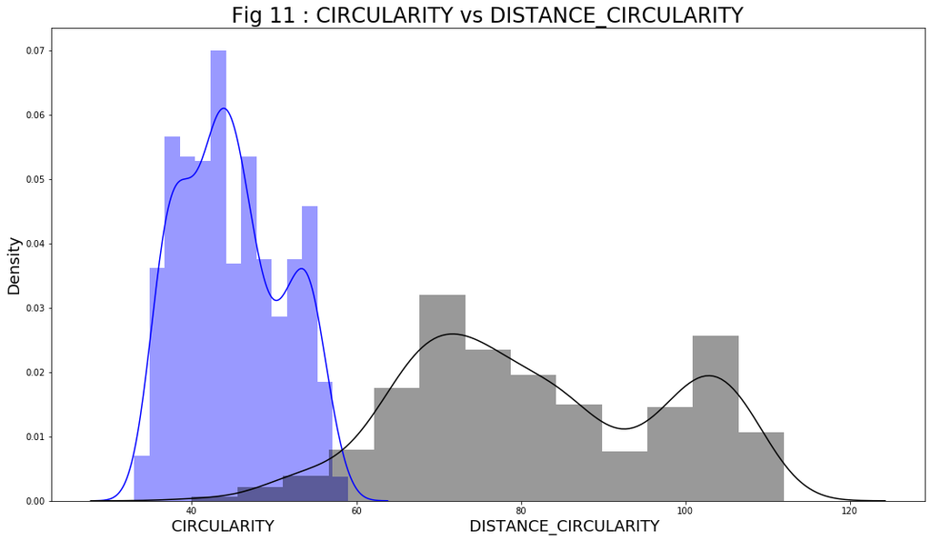

```python
f = plt.subplots(figsize = (18, 10))

sns.distplot(vehicle['CIRCULARITY'], color = "blue", kde = True)

sns.distplot(vehicle['DISTANCE_CIRCULARITY'], color = "black", kde = True)


plt.xlabel("CIRCULARITY                                       DISTANCE_CIRCULARITY                             ", size = 18)
plt.ylabel("Density", size = 18)
plt.title("Fig 11 : CIRCULARITY vs DISTANCE_CIRCULARITY", size = 24)
```

Circularity has the highest density than the distance circularity.

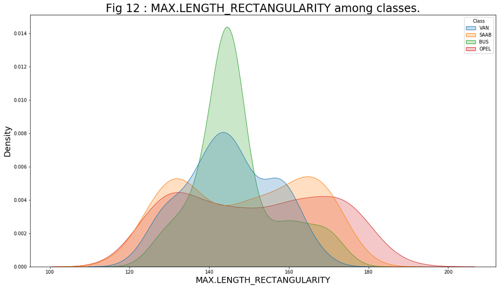

```python
f = plt.subplots(figsize = (18, 10))

sns.kdeplot(vehicle['MAX.LENGTH_RECTANGULARITY'], hue = vehicle["Class"], shade = True)

plt.xlabel("MAX.LENGTH_RECTANGULARITY", size = 18)
plt.ylabel("Density", size = 18)
plt.title("Fig 12 : MAX.LENGTH_RECTANGULARITY among classes.", size = 24)
```

**3 Variable Visualisation**

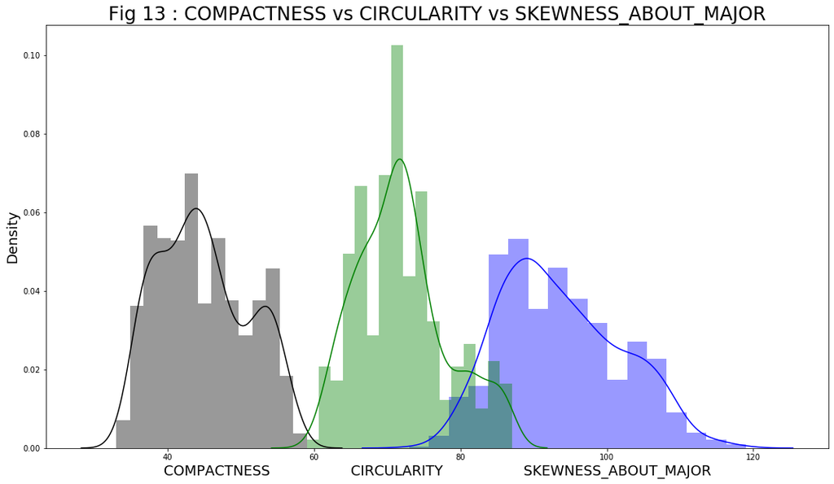

```python
f = plt.subplots(figsize = (18, 10))

sns.distplot(vehicle['COMPACTNESS'], color = "blue", kde = True)

sns.distplot(vehicle['CIRCULARITY'], color = "black", kde = True)

sns.distplot(vehicle['SKEWNESS_ABOUT_MAJOR'], color = "green", kde = True)

plt.xlabel("COMPACTNESS                  CIRCULARITY                  SKEWNESS_ABOUT_MAJOR", size = 18)
plt.ylabel("Density", size = 18)
plt.title("Fig 13 : COMPACTNESS vs CIRCULARITY vs SKEWNESS_ABOUT_MAJOR", size = 24)
```

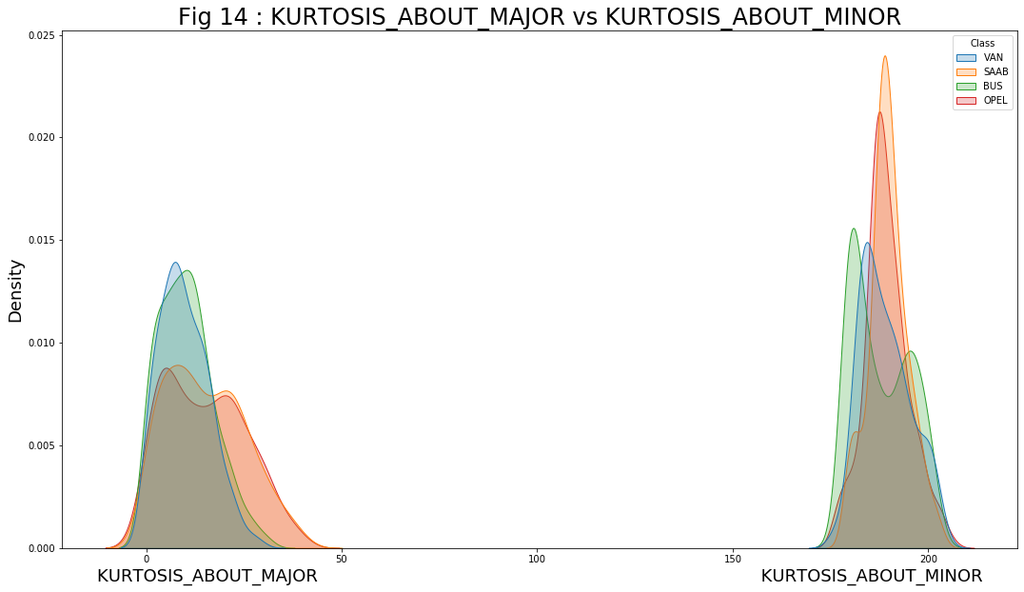

```python
f = plt.subplots(figsize = (18, 10))

sns.kdeplot(vehicle['KURTOSIS_ABOUT_MAJOR'], hue = vehicle["Class"], shade = True)

sns.kdeplot(vehicle['KURTOSIS_ABOUT_MINOR'], hue = vehicle["Class"], shade = True)

plt.xlabel("KURTOSIS_ABOUT_MAJOR                                                                                 KURTOSIS_ABOUT_MINOR", size = 18)
plt.ylabel("Density", size = 18)
plt.title("Fig 14 : KURTOSIS_ABOUT_MAJOR vs KURTOSIS_ABOUT_MINOR", size = 24)
```

1. KURTOSIS_ABOUT_MAJOR density is higher in VAN vehicle type where KURTOSIS_ABOUT_MINOR density is low compared to difeerent vehicles
2. SAAB vehicle density is higher in KURTOSIS_ABOUT_MINOR and OPEL has the minimum density in KURTOSIS_ABOUT_MAJOR

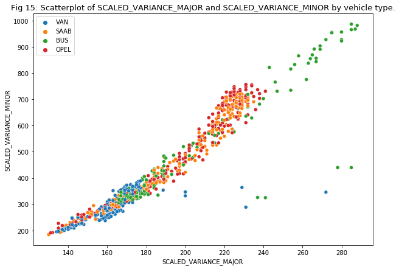

```python
f = plt.subplots(figsize = (10, 7))

sns.scatterplot(vehicle['SCALED_VARIANCE_MAJOR'], vehicle['SCALED_VARIANCE_MINOR'], hue = vehicle['Class'])
plt.title('Fig 15: Scatterplot of SCALED_VARIANCE_MAJOR and SCALED_VARIANCE_MINOR by vehicle type.', fontsize = 13);
plt.legend(loc = 2)
plt.show()
```

SCALED_VARIANCE_MAJOR and SCALED_VARIANCE_MINOR are strongly related to each other. They show a high linear relation ship.

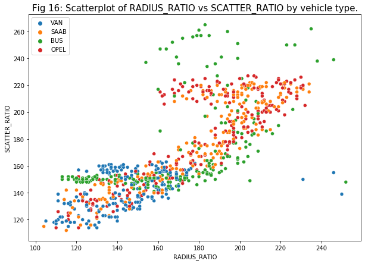

```python
f = plt.subplots(figsize = (10, 7))

sns.scatterplot(vehicle['RADIUS_RATIO'], vehicle['SCATTER_RATIO'], hue = vehicle['Class'])
plt.title('Fig 16: Scatterplot of RADIUS_RATIO vs SCATTER_RATIO by vehicle type.', fontsize = 15)
plt.legend(loc = 2)
plt.show()
```

On increasing the radius ratio all the vehicle types scatter ratio is also increased gradually excluding VAN type. Van type has a minimum rose initially and maintained constant scatter ratio on increasing radius ratio. They show some strength in the relativity.

# Summary and Conclusions

```
• After loading the data, data types are observed and respective conversions are made.
• The data is now checked for missing values, obvious errors, or typos, white spaces and outliers and manipulated accordingly.
• The target variable is converted to upper case.
• After cleaning the data descriptive statistics on the numeric data are calculated.
• The data is now visualised and checked for normality. This is done in the phase 2 i.e., Data Modelling Data pre-processing.
• The data is skewed data. Hence, Normalisation and transformations are to be done.
• This scaling helps in the better prediction of the model i.e., more accurate predictions from the data can be obtained.
• Radios ratio and Scatter ratio are linearly co-related.
• SCALED_VARIANCE_MAJOR and SCALED_VARIANCE_MINOR are strongly related to each other. They show a high linear relation ship.
• Majority of the Sillouttes are of type BUS followed by SAAB, OPEL and VAN respectively.
• This classification will be predicted using 5 different Machine Learning models in Phase 2.
• But before Modelling Data is to be scalled.
• Then the data is split into Test, Train and Validation sets as required.
• The final predictions are then noted and analyzed.
```

# References

1. Vanschoren, J. (2021). OpenML. Retrieved 11 April 2021, from https://www.openml.org/d/54
2. UCI Machine Learning Repository: Statlog (Vehicle Silhouettes) Data Set. (2021). Retrieved 11 April 2021, from https://archive.ics.uci.edu/ml/datasets/Statlog+(Vehicle+Silhouettes)
3. https://stackoverflow.com/questions/64487685/seaborn-attributeerror-module-seaborn-has-no-attribute-displot-and-conda-so
4. Regression Case Study | www.featureranking.com. (2021). Retrieved 11 April 2021, from https://www.featureranking.com/tutorials/statistics-tutorials/regression-case-study/